# 100 Years of Social Work Research: A Data Science Perspective

# Data collection

- Article record retrieval date: January 8, 2015 Database: PsychInfo and Social Science Index (via EbscoHost Platform)
- Search terms: SO “social work” or SO “social welfare” or SO “social casework” or “social case work” or SO “social service” or “social services” or SO “human service” or SO “human services” or SO “social development” or SO “social environment”
- Search limiters: Publication Type: Peer Reviewed Journal; Document Type: Journal Article
- Search modes: Boolean/Phrase
- Search results were exported from EbscoHost Platformon in a *generic bibliographic format*. This is an unstructured text file (*.txt) that was processed using in R.
- EbscoHost full journal listing retrieval date: January 11, 2015 (http://www.ebscohost.com/title-lists)

# Data Pre-Processing

```r
# Clear workspace
rm(list=ls())

# Read BWR functions for Mac OS
source("/Users/beperron/Git/BibWrangleR/functions/piWrangleR.R")
source("/Users/beperron/Git/BibWrangleR/functions/packages.R")
# Set the path where original raw data are stored
setwd("/Users/beperron/Git/SocialWorkResearch/Data")

# Set the working directory to store files created by BWR functions
path <- "/Users/beperron/Git/SocialWorkResearch/Data"

# Wrangle the data with the BWR function suite
#piBWR.f(csv=FALSE, path=path)
#save(pi.df, file = "piArticles.R")
```

```
[1] 545365      3
```

```
[1] "attributes" "articleID"  "record"
```

```
[1] 26572
```

Journals excluded from search results. *Social Work* today excluded because it is of a magazine format.

```r
pi.df <- pi.df %>% filter(
        record != "Journal of Applied Social Sciences" &
        record != "Early Child Development and Care" &
        record != "The Clinical Supervisor" &
        record != "Children and Youth Services Review" &
        record != "General Hospital Psychiatry" &
        record != "Canadian Journal on Aging" &
        record != "Canadian Journal of Community Mental Health" &
        record != "Behavior Modification" &
        record != "Employee Assistance Quarterly" &
        record != "Journal of Applied Behavioral Science" &
        record != "The Scientific Review of Mental Health Practice: Objective Investigations of Controversial and Unorthodox Claims in Clinical Psychology, Psychiatry, and Social Work" &
        record != "Systems Research and Behavioral Science" &
        record != "Journal of Applied Rehabilitation Counseling" &
        record != "Journal of Educational & Psychological Consultation" &
        record != "Journal of Community & Applied Social Psychology" &
        record != "Evaluation and Program Planning" &
        record != "Journal of Nonverbal Behavior" &
        record != "Brain and Cognition" &
        record != "Early Education and Development" &
        record != "American Journal of Preventive Medicine" &
        record != "Social Work Today")
```

Two journal titles were merged because one set of records was a logical abbreviation of another set of records.

```r
pi.df$record <- ifelse(pi.df$record == "Practice", "Practice: Social Work in Action"
                , pi.df$record)
pi.df$articleID <- ifelse(pi.df$articleID == 74, 42, pi.df$articleID)

pi.df$record <- ifelse(pi.df$record == "Eugenics & Social Welfare Bull.", "Eugenics and Social Welfare Bulletin", pi.df$record)
pi.df$articleID <- ifelse(pi.df$articleID == 28, 32, pi.df$articleID)
```

# Preliminary Analyses

All analyses provided here are not in publishable format, but presented to determine the basis of a storyline. All tables and figures will be styled according to a target journal.

## Summary of all journal titles included in the analysis

To do:

- In the table, include the first and last years of indexing, and the numbers of articles.
- Write the script to output a *.csv file so that it can be included as an Appendix without any formatting.

```
## [1] 87
```

```
##  [1] "Clinical Social Work Journal"
##  [2] "Indian Journal of Psychiatric Social Work"
##  [3] "British Journal of Social Work"
##  [4] "Indian Journal of Social Work"
##  [5] "Social Casework"
##  [6] "Social Work"
##  [7] "Smith College Studies in Social Work"
##  [8] "British Journal of Psychiatric Social Work"
##  [9] "Journal of Sociology and Social Welfare"
## [10] "Journal of Social Welfare"
## [11] "Social Work in Health Care"
## [12] "Social Service Review"
## [13] "Journal of Psychiatric Social Work"
## [14] "Medical Social Work"
## [15] "Jewish Social Services Quarterly"
```

[output cut: 72 more lines]

## Count of unique journal titles over time

To do: + Integrate the full journal listing of EbscoHost + Plot overall number of journals over time + Plot overall number of journals by major discipline category as defined by EbscoHost classification – use sociology, anthropology, economics, psychology, and political science

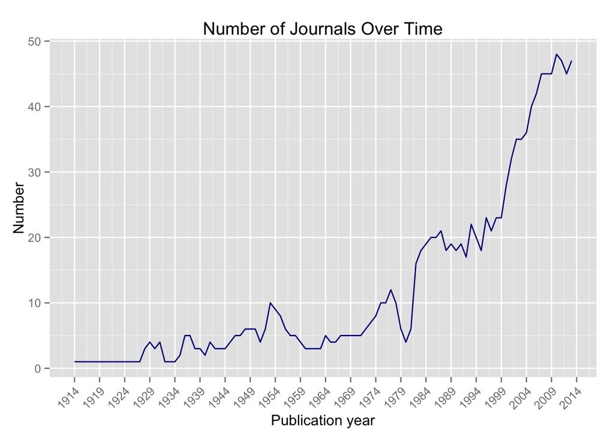

## Growth of Social Work compared to growth of the social sciences

```r
ebscoFullListing.df <- ebscoFullListing.df[ebscoFullListing.df$SourceType == "Academic Journal",]
ebscoFullListing.df$IndexingStart <- format(as.Date(ebscoFullListing.df$IndexingStart, "%m/%d/%Y"), "%Y")
ebscoFullListing.df$IndexingStop <- format(as.Date(ebscoFullListing.df$IndexingStop, "%m/%d/%Y"), "%Y")
ebJournals.df <- ebscoFullListing.df %>% filter(SourceType == "Academic Journal") %>%
    select(Discipline, IndexingStart, IndexingStop, PublicationName, ISSN) %>%
    mutate(IndexingStart = as.numeric(IndexingStart), IndexingStop = as.numeric(IndexingStop)) %>%
    filter(Discipline == "Sociology" | Discipline == "Political Science & Studies"|
           Discipline == "Psychology"| Discipline == "Economics" | Discipline == "Anthropology")

ebJournals.df.unique <- ebJournals.df %>% select(ISSN)
ebJournals.df.unique <- !duplicated(ebJournals.df.unique)
ebJournals.df <- ebJournals.df[ebJournals.df.unique, ]



ebJournals.df <- ebJournals.df[!(ebJournals.df$PublicationName %in% journals.unique),]

ebJournals.df <- select(ebJournals.df, -PublicationName, -ISSN) %>%
    mutate(journalID = c(1:nrow(ebJournals.df))) %>%
    mutate(journalID = as.factor(journalID)) %>%
    select(-Discipline)

#ebJournals.melted <- melt(ebJournals.df)

#ebJournals.overtime.start <- ebJournals.melted %>%
#    filter(value = !is.na(value)) %>%
#    group_by(Discipline, value) %>%
#    summarise(N.start = n())

#ebJournals.overtime.end <- ebJournals.melted %>%
#    filter(variable == "IndexingStop"  & !is.na(value)) %>%
#    group_by(Discipline, value) %>%
#    summarise(N.end = n())

#ebjournals.joined <- left_join(ebJournals.overtime.start, ebJournals.overtime.end) %>%
#    mutate(N.end = ifelse(is.na(N.end), 0, N.end), Cumulative = cumsum(N.start)) %>%
#    mutate(N.adjusted = Cumulative - N.end)


ebJournals.melted.d <- melt(ebJournals.df)
ebJournals.overtime.start.d <- ebJournals.melted.d %>%
    filter(value = !is.na(value)) %>%
    group_by(value) %>%
    summarise(N.start = n())

ebJournals.overtime.end.d <- ebJournals.melted.d %>%
    filter(variable == "IndexingStop"  & !is.na(value)) %>%
    group_by(value) %>%
    summarise(N.end = n())

ebjournals.joined.d <- left_join(ebJournals.overtime.start.d, ebJournals.overtime.end.d) %>%
    mutate(N.end = ifelse(is.na(N.end), 0, N.end), Cumulative = cumsum(N.start)) %>%
    mutate(N.adjusted = Cumulative - N.end)
```

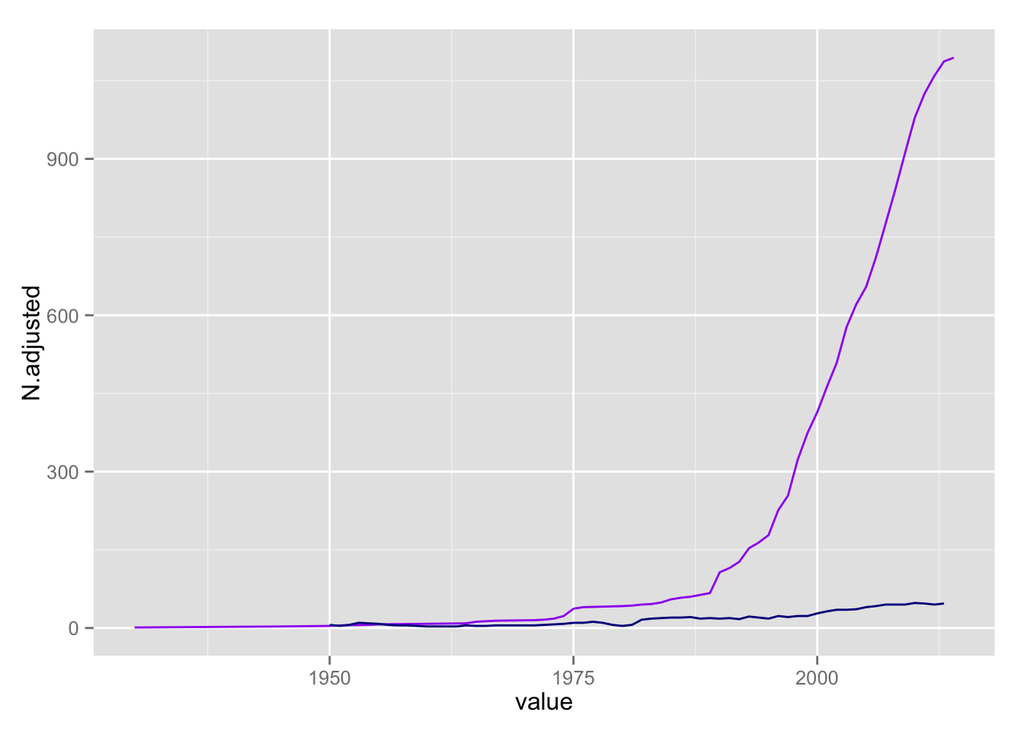

```r
journal.time.reduced <- n.journals.year %>% filter(year >= 1950)
ggplot() +
    geom_line(data = ebjournals.joined.d, aes(x=value, y=N.adjusted), group=1, colour="purple") +
    geom_line(data = journal.time.reduced, aes(as.numeric(year), y=n), group=1, colour="darkblue")
```

## What journals published the most number of articles

```
## Source: local data frame [10 x 4]
##
##                                    title first last n.to.date
## 1                            Social Work  1948 2013      1828
## 2         British Journal of Social Work  1971 2013      1407
## 3                    Families in Society  1990 2013      1186
## 4  Journal of Gerontological Social Work  1981 2013      1135
## 5             Social Work in Health Care  1975 2013      1112
## 6                        Social Casework  1950 1989      1088
## 7   Smith College Studies in Social Work  1930 2013      1050
## 8           Clinical Social Work Journal  1973 2013      1027
## 9       Research on Social Work Practice  1991 2013       928
## 10                  Health & Social Work  1976 2013       889
```

## What is the lifespan of journals?

To do: + Incorporate all EbscoHost journals and the separate disciplinary journals

```
## Source: local data frame [6 x 4]
##
##                                  title stop event first
## 1                Social Service Review   86     0  1927
## 2 Smith College Studies in Social Work   83     0  1930
## 3                          Social Work   65     0  1948
## 4               Journal of Social Work   49     0  1964
## 5        Indian Journal of Social Work   45     1  1941
## 6       British Journal of Social Work   42     0  1971
```

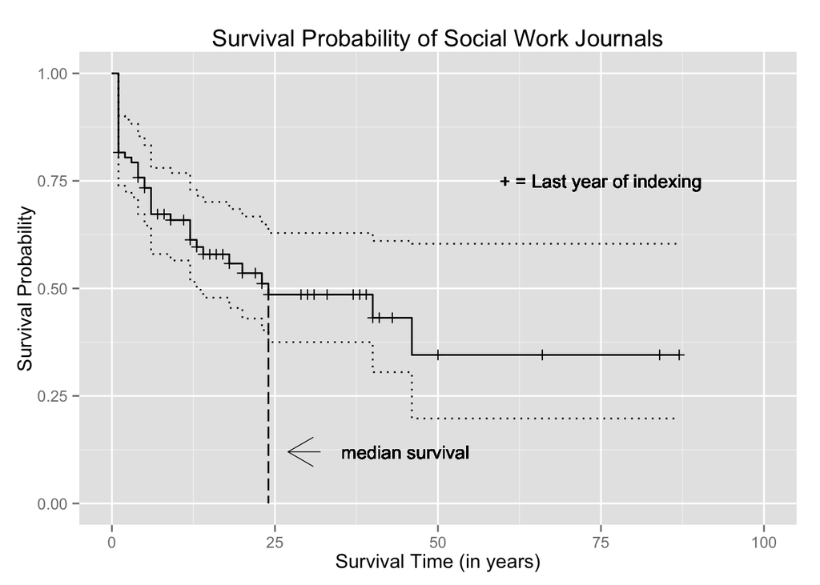

## What is the number of articles published per year

To do: + Plot against major disciplinary categories

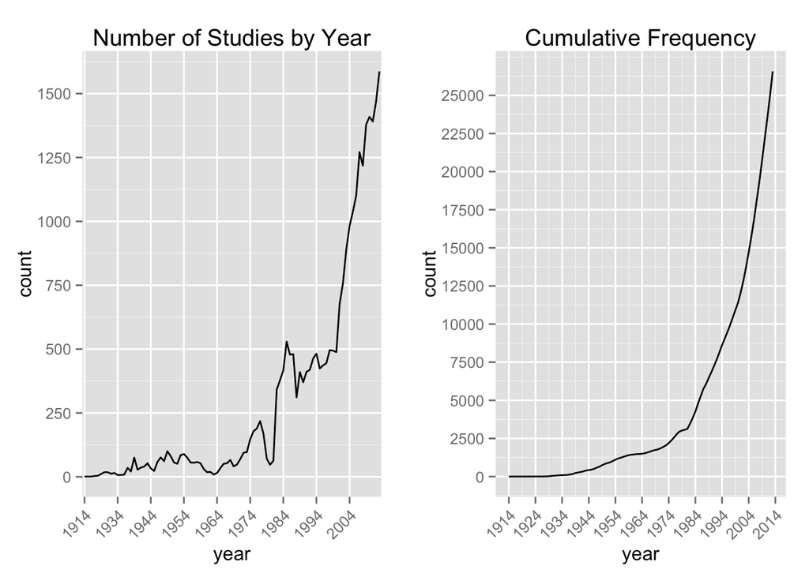

```
##    years year.count
## 81  2004        982
## 82  2005       1038
## 83  2006       1101
## 84  2007       1271
## 85  2008       1218
## 86  2009       1379
## 87  2010       1409
## 88  2011       1391
## 89  2012       1469
## 90  2013       1587
```

# What are the most frequent topic areas (by author specified keywords)?

To do:  
+ Fix script that performs matching – convert all keywords to lower before matching

```
$subject.terms.total
[1] 111806

$subject.terms.unique
[1] 50736
```

```
             subject.terms Freq
1               socialwork 1883
2            socialworkers 1798
3      socialworkeducation  737
4       socialworkpractice  538
5                 children  355
6           socialservices  334
7             mentalhealth  319
8       socialworkstudents  315
9             childwelfare  269
10 childhoodandadolescence  252
11                  family  252
12                     hiv  247
13           socialsupport  237
14             riskfactors  230
15          socialcasework  222
16              fostercare  219
17             adolescents  213
18           psychotherapy  211
19                   india  202
20            spirituality  198
21             methodology  196
22                 poverty  194
23            intervention  183
24              depression  182
25          decisionmaking  181
```

## Most Frequent Author Keywords

*DO NOT INTERPRET RESULTS HERE THIS SECTION IS NOT WORKING PROPERLY*

For this analysis (to-do), select a few keywords that may tell an interesting story of how they change over time – something that might be revealing of ‘trends.’

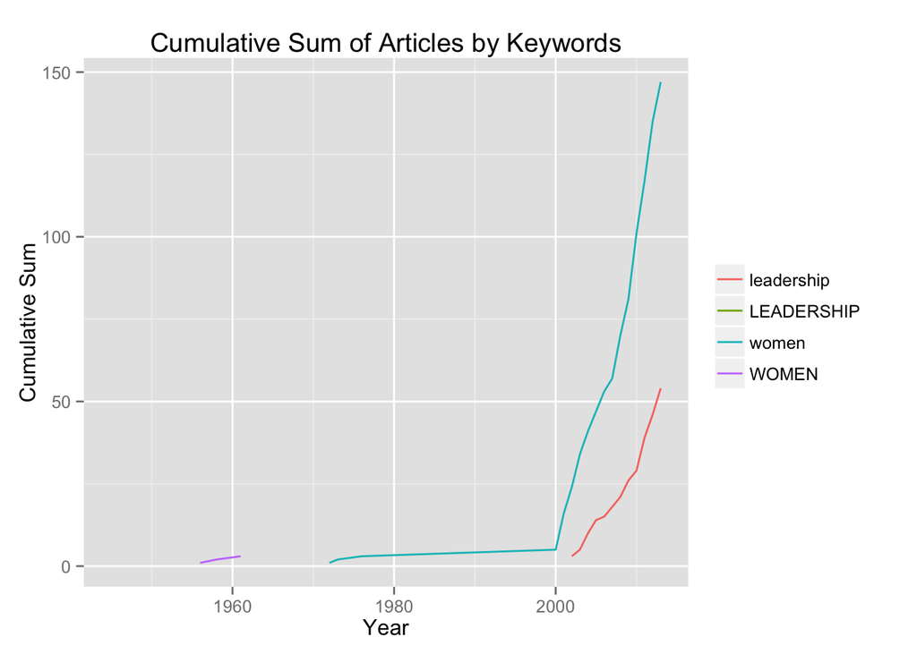

## Location of Studies

To do: + Determine best format / presentation of map

## Location of studies over time

To do: + Determine best format / presentation of map

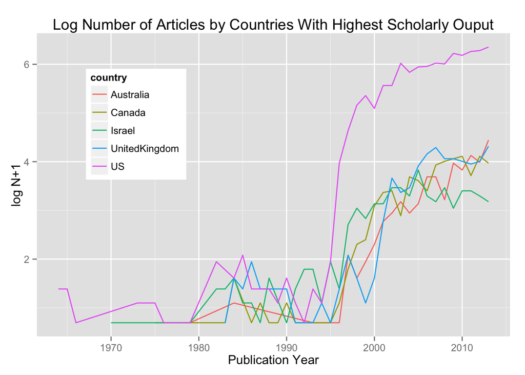

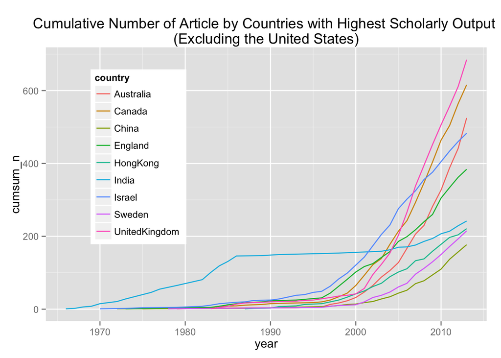

## Countries represents in the social work research

To do: + Obtain definition of `LO` tag.  
+ Determine how many articles had LO tag (note the issue if not included from Social Science Index)

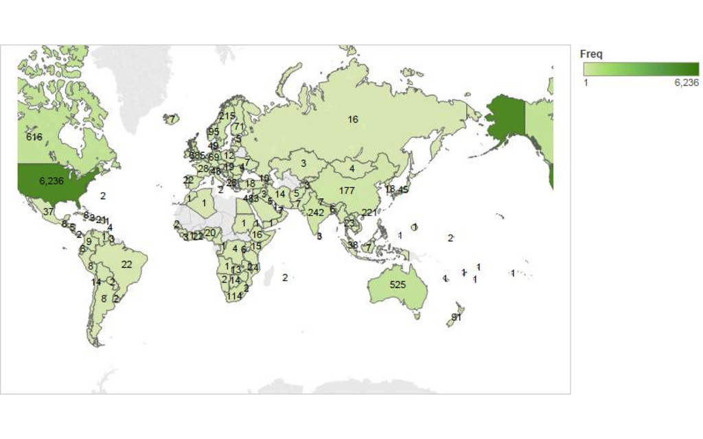

## Countries not represented in social work research

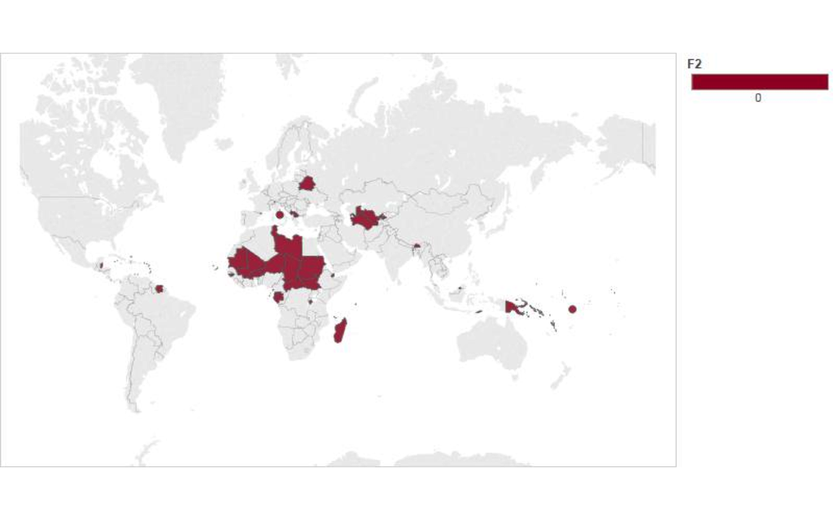

## Number of authors

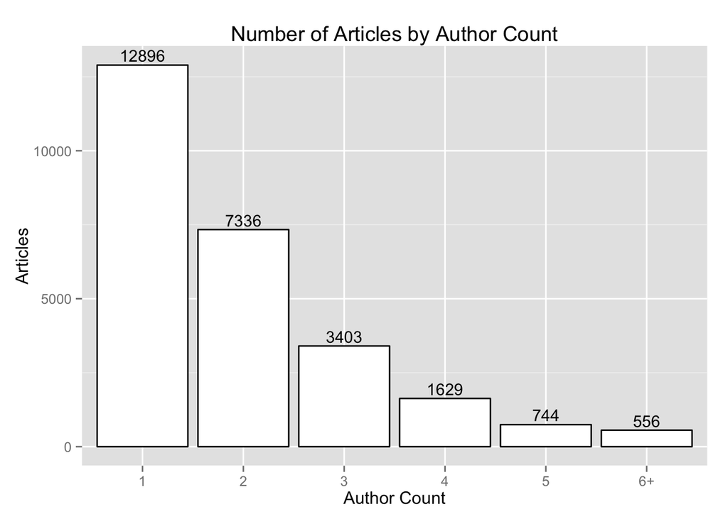

## Number of authors over time

This figure shows the average number of authors, along with the standard deviation as the ribbon around the average. Note that there is a possible problem in these data, with a single article listing a huge number. That can be corrected at a later time.

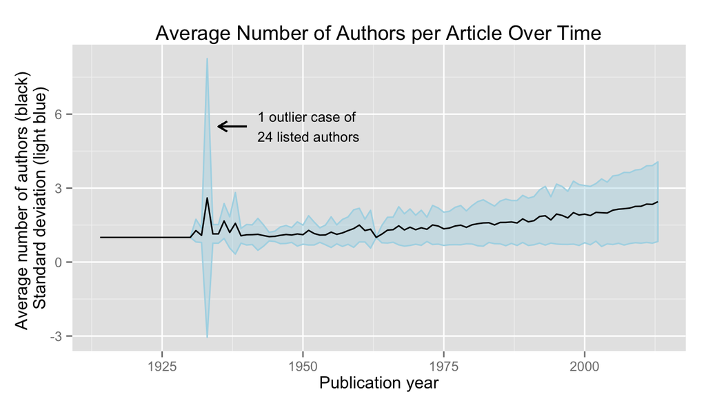

[output not shown]